# IST 5535 Lab 2: Collinearity

Sayantan Majumdar

2020-02-13

# 1 Initialization

```r
set.seed(1)
x1 <- runif(100)
x2 <- 0.5 * x1 + rnorm(100) / 10
y <- 2 + 2 * x1 + 0.3 * x2 + rnorm(100)
```

Linear model: $y = 2 + 2x_1 + 0.3x_2$ with $\beta_0=2, \beta_1=2,$ and $\beta_2=0.3$.

# 2 Correlation

```r
cor(x1, x2)
```

```
## [1] 0.8351212
```

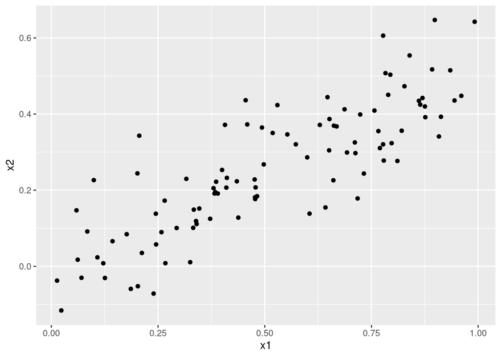

```r
library(ggplot2)
qplot(x=x1, y=x2)
```

$x_1$ and $x_2$ have high positive correlation.

# 3 Regression using x1 and x2

```r
model1 <- lm(y ~ x1 + x2)
summary(model1)
```

```
##
## Call:
## lm(formula = y ~ x1 + x2)
##
## Residuals:
##     Min      1Q  Median      3Q     Max
## -2.8311 -0.7273 -0.0537  0.6338  2.3359
##
## Coefficients:
##             Estimate Std. Error t value Pr(>|t|)
## (Intercept)   2.1305     0.2319   9.188 7.61e-15 ***
## x1            1.4396     0.7212   1.996   0.0487 *
## x2            1.0097     1.1337   0.891   0.3754
## ---
## Signif. codes:  0 '***' 0.001 '**' 0.01 '*' 0.05 '.' 0.1 ' ' 1
##
## Residual standard error: 1.056 on 97 degrees of freedom
## Multiple R-squared:  0.2088, Adjusted R-squared:  0.1925
## F-statistic:  12.8 on 2 and 97 DF,  p-value: 1.164e-05
```

$\beta_0$ and $\beta_1$ are estimated wth sufficiently high accuracy. However, the estimated $\beta_2$ has high error. Moreover, the summary statistics show that $\beta_2$ is not statistically significant.

We can reject $H_0: \beta_1=0$ but we fail to reject $H_0: \beta_2=0$.

# 4 Regression using x1

```r
model2 <- lm(y ~ x1)
summary(model2)
```

```
##
## Call:
## lm(formula = y ~ x1)
##
## Residuals:
##      Min       1Q   Median       3Q      Max
## -2.89495 -0.66874 -0.07785  0.59221  2.45560
##
## Coefficients:
##             Estimate Std. Error t value Pr(>|t|)
## (Intercept)   2.1124     0.2307   9.155 8.27e-15 ***
## x1            1.9759     0.3963   4.986 2.66e-06 ***
## ---
## Signif. codes:  0 '***' 0.001 '**' 0.01 '*' 0.05 '.' 0.1 ' ' 1
##
## Residual standard error: 1.055 on 98 degrees of freedom
## Multiple R-squared:  0.2024, Adjusted R-squared:  0.1942
## F-statistic: 24.86 on 1 and 98 DF,  p-value: 2.661e-06
```

Here, the adjusted $R^2$ value increases than before and we can also reject $H_0: \beta_1=0$.

# 5 Regression using x2

```r
model3 <- lm(y ~ x2)
summary(model3)
```

```
##
## Call:
## lm(formula = y ~ x2)
##
## Residuals:
##      Min       1Q   Median       3Q      Max
## -2.62687 -0.75156 -0.03598  0.72383  2.44890
##
## Coefficients:
##             Estimate Std. Error t value Pr(>|t|)
## (Intercept)   2.3899     0.1949   12.26  < 2e-16 ***
## x2            2.8996     0.6330    4.58 1.37e-05 ***
## ---
## Signif. codes:  0 '***' 0.001 '**' 0.01 '*' 0.05 '.' 0.1 ' ' 1
##
## Residual standard error: 1.072 on 98 degrees of freedom
## Multiple R-squared:  0.1763, Adjusted R-squared:  0.1679
## F-statistic: 20.98 on 1 and 98 DF,  p-value: 1.366e-05
```

The adjusted $R^2$ reduces and we can reject $H_0: \beta_1=0$.

# 6 Model Comparison

```r
stargazer::stargazer(model1, model2, model3, type = 'text', star.cutoffs = c(0.05, 0.01, 0.001))
```

```
##
## ========================================================================================
##                                             Dependent variable:
##                     --------------------------------------------------------------------
##                                                      y
##                              (1)                    (2)                    (3)
## ----------------------------------------------------------------------------------------
## x1                          1.440*                1.976***
##                            (0.721)                (0.396)
##
## x2                          1.010                                        2.900***
##                            (1.134)                                       (0.633)
##
## Constant                   2.130***               2.112***               2.390***
##                            (0.232)                (0.231)                (0.195)
##
## ----------------------------------------------------------------------------------------
## Observations                 100                    100                    100
## R2                          0.209                  0.202                  0.176
## Adjusted R2                 0.193                  0.194                  0.168
## Residual Std. Error    1.056 (df = 97)        1.055 (df = 98)        1.072 (df = 98)
## F Statistic         12.802*** (df = 2; 97) 24.862*** (df = 1; 98) 20.980*** (df = 1; 98)
## ========================================================================================
## Note:                                                      *p<0.05; **p<0.01; ***p<0.001
```

# 7 Additional Observation

```r
x1_new <- c(x1, 0.1)
x2_new <- c(x2, 0.8)
y_new <- c(y, 6)
```

## 7.1 New Regression using x1 and x2

```r
model1 <- lm(y_new ~ x1_new + x2_new)
summary(model1)
```

```
##
## Call:
## lm(formula = y_new ~ x1_new + x2_new)
##
## Residuals:
##      Min       1Q   Median       3Q      Max
## -2.73348 -0.69318 -0.05263  0.66385  2.30619
##
## Coefficients:
##             Estimate Std. Error t value Pr(>|t|)
## (Intercept)   2.2267     0.2314   9.624 7.91e-16 ***
## x1_new        0.5394     0.5922   0.911  0.36458
## x2_new        2.5146     0.8977   2.801  0.00614 **
## ---
## Signif. codes:  0 '***' 0.001 '**' 0.01 '*' 0.05 '.' 0.1 ' ' 1
##
## Residual standard error: 1.075 on 98 degrees of freedom
## Multiple R-squared:  0.2188, Adjusted R-squared:  0.2029
## F-statistic: 13.72 on 2 and 98 DF,  p-value: 5.564e-06
```

## 7.2 New Regression using x1

```r
model2 <- lm(y_new ~ x1_new)
summary(model2)
```

```
##
## Call:
## lm(formula = y_new ~ x1_new)
##
## Residuals:
##     Min      1Q  Median      3Q     Max
## -2.8897 -0.6556 -0.0909  0.5682  3.5665
##
## Coefficients:
##             Estimate Std. Error t value Pr(>|t|)
## (Intercept)   2.2569     0.2390   9.445 1.78e-15 ***
## x1_new        1.7657     0.4124   4.282 4.29e-05 ***
## ---
## Signif. codes:  0 '***' 0.001 '**' 0.01 '*' 0.05 '.' 0.1 ' ' 1
##
## Residual standard error: 1.111 on 99 degrees of freedom
## Multiple R-squared:  0.1562, Adjusted R-squared:  0.1477
## F-statistic: 18.33 on 1 and 99 DF,  p-value: 4.295e-05
```

## 7.3 New Regression using x2

```r
model3 <- lm(y_new ~ x2_new)
summary(model3)
```

```
##
## Call:
## lm(formula = y_new ~ x2_new)
##
## Residuals:
##      Min       1Q   Median       3Q      Max
## -2.64729 -0.71021 -0.06899  0.72699  2.38074
##
## Coefficients:
##             Estimate Std. Error t value Pr(>|t|)
## (Intercept)   2.3451     0.1912  12.264  < 2e-16 ***
## x2_new        3.1190     0.6040   5.164 1.25e-06 ***
## ---
## Signif. codes:  0 '***' 0.001 '**' 0.01 '*' 0.05 '.' 0.1 ' ' 1
##
## Residual standard error: 1.074 on 99 degrees of freedom
## Multiple R-squared:  0.2122, Adjusted R-squared:  0.2042
## F-statistic: 26.66 on 1 and 99 DF,  p-value: 1.253e-06
```

## 7.4 New Model Comparison

```r
stargazer::stargazer(model1, model2, model3, type = 'text', star.cutoffs = c(0.05, 0.01, 0.001))
```

```
##
## ========================================================================================
##                                             Dependent variable:
##                     --------------------------------------------------------------------
##                                                    y_new
##                              (1)                    (2)                    (3)
## ----------------------------------------------------------------------------------------
## x1_new                      0.539                 1.766***
##                            (0.592)                (0.412)
##
## x2_new                     2.515**                                       3.119***
##                            (0.898)                                       (0.604)
##
## Constant                   2.227***               2.257***               2.345***
##                            (0.231)                (0.239)                (0.191)
##
## ----------------------------------------------------------------------------------------
## Observations                 101                    101                    101
## R2                          0.219                  0.156                  0.212
## Adjusted R2                 0.203                  0.148                  0.204
## Residual Std. Error    1.075 (df = 98)        1.111 (df = 99)        1.074 (df = 99)
## F Statistic         13.724*** (df = 2; 98) 18.333*** (df = 1; 99) 26.664*** (df = 1; 99)
## ========================================================================================
## Note:                                                      *p<0.05; **p<0.01; ***p<0.001
```

With this new observation, $x_2$ is has become the statistically significant predictor and we see that the adjusted $R^2$ increases when $x_2$ is present in the models. When we only consider $x_1$, the adjusted $R^2$ decreases.

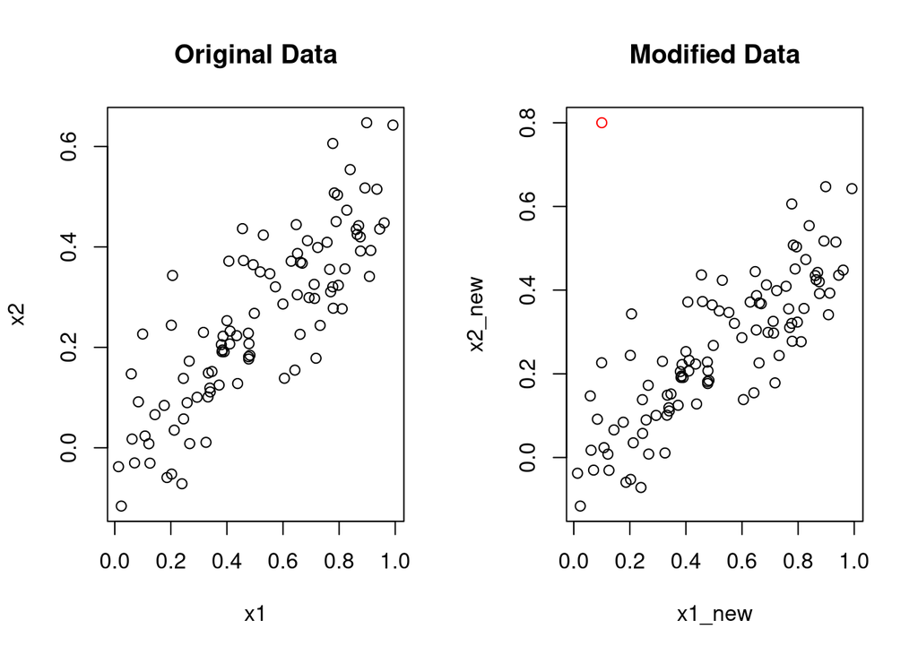

```r
par(mfrow = c(1, 2))
plot(x = x1, y = x2, main = "Original Data")
plot(x = x1_new, y = x2_new, main = "Modified Data", col = ifelse(x1_new == 0.1, "red", "black"))
```

From these two plots we clearly see that the new data point is an outlier (marked in red).